# raw 데이터 탐색

## 상품 금액의 정규성 검정

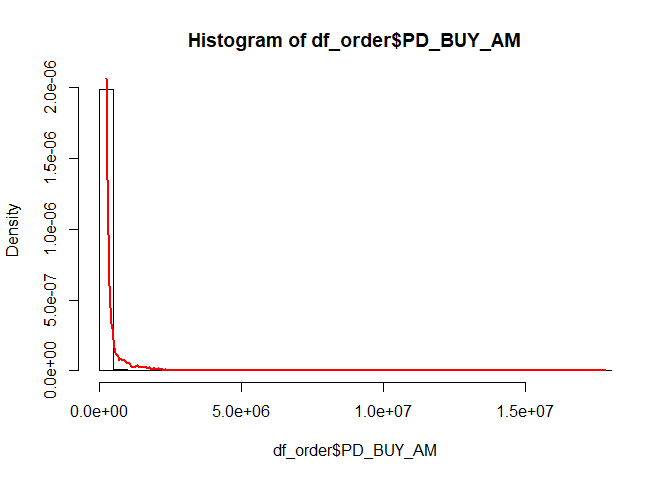

```r
# 변수 변환 전 정규성 검정

# 1) 확률밀도 그래프 - 정규성 따르지 않음
hist(df_order$PD_BUY_AM, freq = F, breaks = 50)
lines(density(df_order$PD_BUY_AM), col = 'red', lwd = 2)
```

```r
# 2) Q-Q Plot - 정규성 따르지 않음
library(ggpubr)

# ggqqplot(df_order$PD_BUY_AM, color = 'red')
```

```r
# 3) Shapiro Test - 크기가 커서 shapiro test 불가
# shapiro.test(df_order$PD_BUY_AM)

# Error in shapiro.test(df_order$PD_BUY_AM) :
# sample size must be between 3 and 5000
```

```r
# 4) Anderson-Darling normality test
library(nortest)

ad.test(df_order$PD_BUY_AM)
```

```
##
##  Anderson-Darling normality test
##
## data:  df_order$PD_BUY_AM
## A = 707577, p-value < 2.2e-16
```

```r
# 5) Cramer-von Mises normality test
cvm.test(df_order$PD_BUY_AM)
```

```
##
##  Cramer-von Mises normality test
##
## data:  df_order$PD_BUY_AM
## W = 139620, p-value = 7.37e-10
```

```r
# 6) Lilliefors normality test
lillie.test(df_order$PD_BUY_AM)
```

```
##
##  Lilliefors (Kolmogorov-Smirnov) normality test
##
## data:  df_order$PD_BUY_AM
## D = 0.32868, p-value < 2.2e-16
```

```r
# 7) Pearson chi-square normality test
pearson.test(df_order$PD_BUY_AM)
```

```
##
##  Pearson chi-square normality test
##
## data:  df_order$PD_BUY_AM
## P = 26721967, p-value < 2.2e-16
```

- 정규성 검정 결과, 귀무가설이 기각되어 정규성을 따르지 않는다.

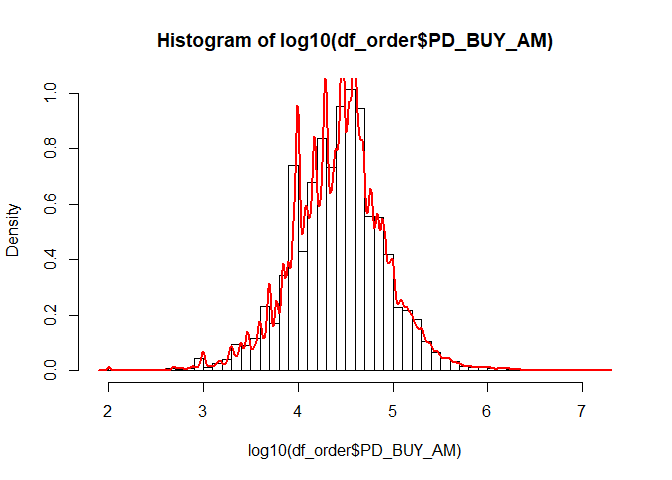

```r
# (2) 변수변환(log10) 후 정규성 검정

# 1) 확률밀도 그래프
# library(ggpubr)
#
# ggdensity(log10(df_order$PD_BUY_AM),
#           add = 'mean',
#           color = 'red',
#           fill = 'lightblue',
#           alpha = .3,
#           title = '구매액 확률밀도 그래프',
#           xlab = 'log(구매액)')

hist(log10(df_order$PD_BUY_AM), freq = F, breaks = 50)
lines(density(log10(df_order$PD_BUY_AM)), col = 'red', lwd = 2)
```

```r
# 2) Q-Q Plot
# qqnorm(log10(df_order$PD_BUY_AM))
# qqline(log10(df_order$PD_BUY_AM))
```

```r
# 3) Shapiro Test - 크기가 커서 shapiro test 불가
# shapiro.test(log10(df_order$PD_BUY_AM))
#
# Error in shapiro.test(log10(df_order$PD_BUY_AM)) :
# sample size must be between 3 and 5000
```

```r
# 4) Anderson-Darling normality test
library(nortest)

ad.test(log10(df_order$PD_BUY_AM))
```

```
##
##  Anderson-Darling normality test
##
## data:  log10(df_order$PD_BUY_AM)
## A = 8316.6, p-value < 2.2e-16
```

```r
# 5) Cramer-von Mises normality test
cvm.test(log10(df_order$PD_BUY_AM))
```

```
##
##  Cramer-von Mises normality test
##
## data:  log10(df_order$PD_BUY_AM)
## W = 1359.7, p-value = 7.37e-10
```

```r
# 6) Lilliefors normality test
lillie.test(log10(df_order$PD_BUY_AM))
```

```
##
##  Lilliefors (Kolmogorov-Smirnov) normality test
##
## data:  log10(df_order$PD_BUY_AM)
## D = 0.036062, p-value < 2.2e-16
```

```r
# 7) Pearson chi-square normality test
pearson.test(log10(df_order$PD_BUY_AM))
```

```
##
##  Pearson chi-square normality test
##
## data:  log10(df_order$PD_BUY_AM)
## P = 14742542, p-value < 2.2e-16
```

- 정규성 검정 결과, 귀무가설이 기각되어 정규성을 따르지 않는다.

## 구매액 정규성 검정

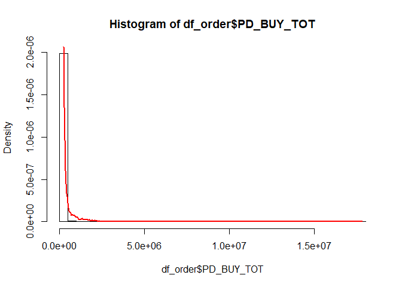

```r
# 변수 변환 전 정규성 검정

# 1) 확률밀도 그래프 - 정규성 따르지 않음
hist(df_order$PD_BUY_TOT, freq = F, breaks = 50)
lines(density(df_order$PD_BUY_AM), col = 'red', lwd = 2)
```

```r
# 2) Q-Q Plot - 정규성 따르지 않음
library(ggpubr)

# ggqqplot(df_order$PD_BUY_TOT, color = 'red')
```

```r
# 3) Shapiro Test - 크기가 커서 shapiro test 불가
# shapiro.test(df_order$PD_BUY_TOT)
#
# Error in shapiro.test(df_order$PD_BUY_TOT) :
# sample size must be between 3 and 5000
```

```r
# 4) Anderson-Darling normality test
library(nortest)

ad.test(df_order$PD_BUY_TOT)
```

```
##
##  Anderson-Darling normality test
##
## data:  df_order$PD_BUY_TOT
## A = 708683, p-value < 2.2e-16
```

```r
# 5) Cramer-von Mises normality test
cvm.test(df_order$PD_BUY_TOT)
```

```
##
##  Cramer-von Mises normality test
##
## data:  df_order$PD_BUY_TOT
## W = 139914, p-value = 7.37e-10
```

```r
# 6) Lilliefors normality test
lillie.test(df_order$PD_BUY_TOT)
```

```
##
##  Lilliefors (Kolmogorov-Smirnov) normality test
##
## data:  df_order$PD_BUY_TOT
## D = 0.32784, p-value < 2.2e-16
```

```r
# 7) Pearson chi-square normality test
pearson.test(df_order$PD_BUY_TOT)
```

```
##
##  Pearson chi-square normality test
##
## data:  df_order$PD_BUY_TOT
## P = 28306843, p-value < 2.2e-16
```

- 정규성 검정 결과, 귀무가설이 기각되어 정규성을 따르지 않는다.

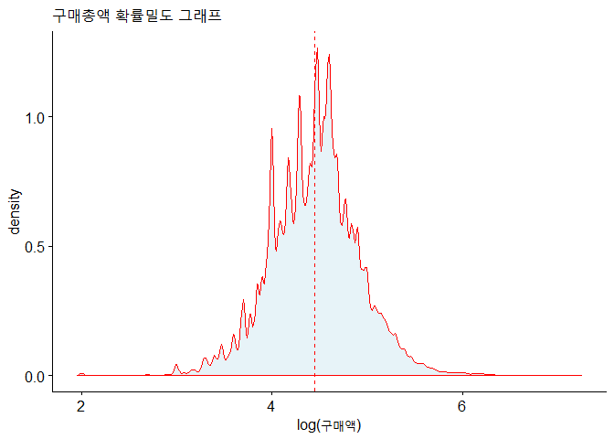

```r
# (2) 변수변환(log10) 후 정규성 검정

# 1) 확률밀도 그래프
library(ggpubr)

ggdensity(log10(df_order$PD_BUY_TOT),
          add = 'mean',
          color = 'red',
          fill = 'lightblue',
          alpha = .3,
          title = '구매총액 확률밀도 그래프',
          xlab = 'log(구매액)')
```

```r
# 2) Q-Q Plot
# qqnorm(log10(df_order$PD_BUY_TOT))
# qqline(log10(df_order$PD_BUY_TOT))
```

```r
# 3) Shapiro Test - 크기가 커서 shapiro test 불가
# shapiro.test(log10(df_order$PD_BUY_TOT))
#
# Error in shapiro.test(log10(df_order$PD_BUY_TOT)) :
# sample size must be between 3 and 5000
```

```r
# 4) Anderson-Darling normality test
library(nortest)

ad.test(log10(df_order$PD_BUY_TOT))
```

```
##
##  Anderson-Darling normality test
##
## data:  log10(df_order$PD_BUY_TOT)
## A = 6075.5, p-value < 2.2e-16
```

```r
# 5) Cramer-von Mises normality test
cvm.test(log10(df_order$PD_BUY_TOT))
```

```
##
##  Cramer-von Mises normality test
##
## data:  log10(df_order$PD_BUY_TOT)
## W = 998.41, p-value = 7.37e-10
```

```r
# 6) Lilliefors normality test
lillie.test(log10(df_order$PD_BUY_TOT))
```

```
##
##  Lilliefors (Kolmogorov-Smirnov) normality test
##
## data:  log10(df_order$PD_BUY_TOT)
## D = 0.036899, p-value < 2.2e-16
```

```r
# 7) Pearson chi-square normality test
pearson.test(log10(df_order$PD_BUY_TOT))
```

```
##
##  Pearson chi-square normality test
##
## data:  log10(df_order$PD_BUY_TOT)
## P = 13921915, p-value < 2.2e-16
```

- 정규성 검정 결과, 귀무가설이 기각되어 정규성을 따르지 않는다.
- 중심극한의 정리에 의해, 대표본인 데이터를 이용하므로 정규성을 따른다는 가정하에 분석을 진행한다.